# CompCat Data Analysis Script

Load libraries

```r
library(reshape2)
library(reshape)
library(stringr)
library(plyr)
library(ggplot2)
library(nlme)
library(pastecs)
library(car)
library(psych)
library(fBasics)
library(Rmisc)
setwd("~/CompCat")
```

# Data Cleaning

We have a few different data sources here.

1. `behavior.csv` contains the behavioral data (assessments, ages, etc.) for all of the participants.
2. `exp_data.csv` contains the experimental data from the main category learning task (collected in E-Prime 2.0).
3. `visualnorm.csv` contains aggregated similarity ratings for all of the stimulus pairings.

In this first step, we will select the relevant columns from `exp_data` and add in 3 types of visual similarity for each trial (probe-target, probe-distractor, and target-distractor), as well as a double-click indicator column for use in RT analyses.

```r
#Read in data
dat0 <- read.csv("exp_data.csv")
visualnorm <- read.csv("visualnorm.csv")
#rename column 1 in visual norming
colnames(visualnorm)[1] <- "Robot"
#select just data from testing
dat1 <- subset(dat0, Block==2)
dat1$condition <- str_match(dat1$ExperimentName, "^([A-Za-z]{1,}_[A-Za-z]{1,})")[, 2]
dat1$train.type <- as.factor(str_match(dat1$ExperimentName, "^([A-Za-z]{1,})_")[, 2])
dat1$train.type <- revalue(dat1$train.type, c("Explicit" = "Directed", "Implicit" = "Undirected"))
dat1$info.type <- as.factor(str_match(dat1$ExperimentName, "^[A-Za-z]{1,}_([A-Za-z]{1,})_")[, 2])
#pick out the important variables --
#we can use Stimulus.Acc for test because there is only one response
# i.e. don't have to use NError
dat2 <- data.frame(dat1$Subject, dat1$condition, dat1$Trial, dat1$Probe_pic,
                      dat1$target_pic, dat1$distractor_pic, dat1$Stimulus.ACC,
                      dat1$Stimulus.RESP, dat1$Stimulus.RT, dat1$info.type, dat1$train.type)
dat2$doubleclick <- NA
#rename columns
names(dat2) <- c("Subj","condition", "Trial", "probepic","target_pic",
                    "distractor_pic","Acc","Resp","RT","info.type", "train.type", "doubleclick")
#if they double clicked, this column has a 1. If not, a 0
#double clicks should be removed when analyzing RT
dat2[dat2$Resp > 2, "doubleclick"] <- 1
dat2[dat2$Resp == 1, "doubleclick"] <- 0

#put visual norming data into a better format
vissim <- melt.data.frame(visualnorm, id.vars="Robot")
names(vissim) <- c("Rob1","Rob2","sim")

#add columns for visual similarity
#probe-target
dat1$vs.pt <- NA
#probe-distractor
dat1$vs.pd <- NA
#target-distractor
dat1$vs.td <- NA

#fill in probe-target visual similarity
#merge e-prime data with visual norming data
vs.pt <- merge(dat2, vissim, by.x=c("probepic", "target_pic"), by.y=c("Rob1", "Rob2"), all=T)
#remove excess columns
vs.pt <- vs.pt[!is.na(vs.pt$Subj),]
#sort by subject and trial
vs.pt.sort<- vs.pt[order(vs.pt$Subj, vs.pt$Trial),]
#put the visual similarity column in the overall data frame
dat2$vs.pt <- vs.pt.sort$sim

#fill in probe-distractor visual similarity
vs.pd <- merge(dat2, vissim, by.x=c("probepic", "distractor_pic"), by.y=c("Rob1", "Rob2"), all=T)
vs.pd <- vs.pd[!is.na(vs.pd$Subj),]
vs.pd.sort<- vs.pd[order(vs.pd$Subj, vs.pd$Trial),]
dat2$vs.pd <- vs.pd.sort$sim

#fill in target-distractor visual similarity
vs.td <- merge(dat2, vissim, by.x=c("target_pic", "distractor_pic"), by.y=c("Rob1", "Rob2"), all=T)
vs.td <- vs.td[!is.na(vs.td$Subj),]
vs.td.sort<- vs.td[order(vs.td$Subj, vs.td$Trial),]
dat2$vs.td <- vs.td.sort$sim
```

Now we will calculate the average accuracy for each subject for each condition.

```r
acc <- data.frame(tapply(dat2$Acc, list(dat2$Subj, dat2$condition), mean))
acc$Subj <- as.numeric(rownames(acc))
acc.melt <- melt.data.frame(acc, id.vars = "Subj")
names(acc.melt) <- c("Subj", "Cond", "Acc")
acc.melt$train.type <- as.factor(str_match(acc.melt$Cond, "^([A-Za-z]{1,})_")[, 2])
acc.melt$train.type <- revalue(acc.melt$train.type, c("Explicit" = "Directed", "Implicit" = "Undirected"))
acc.melt$info.type <- as.factor(str_match(acc.melt$Cond, "^[A-Za-z]{1,}_([A-Za-z]{1,})")[, 2])
```

Now we will merge all of the behavioral data into both the raw data and the aggregated data.

```r
behavior <- read.csv("behavior.csv")
behavior$Group <- factor(behavior$Group, levels(behavior$Group)[c(2,1)])
dat3 <- merge(dat2, behavior, by = "Subj")
acc_beh <- merge(acc.melt, behavior, by = "Subj")
```

# Group Analysis

```r
acc_group <- acc_beh[acc_beh$KTEA_SS <= 90 | acc_beh$KTEA_SS >= 100,]
min(acc_group$WA_SS)
```

```
## [1] 95
```

```r
min(acc_group$P_IQ)
```

```
## [1] 80
```

```r
# check number of subjects
length(table(acc_group$Subj))
```

```
## [1] 39
```

```r
subs_groups <- data.frame(acc_group$Subj, acc_group$Group)
subs_groups <- unique(subs_groups)
table(subs_groups$acc_group.Group)
```

```
##
## TD PC
## 20 19
```

## Descriptive Statistics

```r
beh_group <- behavior[behavior$KTEA_SS <= 90 | behavior$KTEA_SS >= 100,]
by(beh_group$KTEA_SS, list(beh_group$Group), mean)
```

```
## : TD
## [1] 112.55
## --------------------------------------------------------
## : PC
## [1] 84.15789
```

```r
by(beh_group$KTEA_SS, list(beh_group$Group), sd)
```

```
## : TD
## [1] 8.816701
## --------------------------------------------------------
## : PC
## [1] 5.871429
```

```r
t.test(beh_group$KTEA_SS ~ beh_group$Group)
```

```
##
##  Welch Two Sample t-test
##
## data:  beh_group$KTEA_SS by beh_group$Group
## t = 11.891, df = 33.235, p-value = 1.613e-13
## alternative hypothesis: true difference in means is not equal to 0
## 95 percent confidence interval:
##  23.53559 33.24862
## sample estimates:
## mean in group TD mean in group PC
##        112.55000         84.15789
```

```r
by(beh_group$WA_SS, list(beh_group$Group), mean)
```

```
## : TD
## [1] 107.8
## --------------------------------------------------------
## : PC
## [1] 101.7895
```

```r
by(beh_group$WA_SS, list(beh_group$Group), sd)
```

```
## : TD
## [1] 8.563079
## --------------------------------------------------------
## : PC
## [1] 5.798266
```

```r
t.test(beh_group$WA_SS ~ beh_group$Group)
```

```
##
##  Welch Two Sample t-test
##
## data:  beh_group$WA_SS by beh_group$Group
## t = 2.578, df = 33.523, p-value = 0.01451
## alternative hypothesis: true difference in means is not equal to 0
## 95 percent confidence interval:
##   1.269912 10.751141
## sample estimates:
## mean in group TD mean in group PC
##         107.8000         101.7895
```

```r
by(beh_group$P_IQ, list(beh_group$Group), mean)
```

```
## : TD
## [1] 114.65
## --------------------------------------------------------
## : PC
## [1] 94.47368
```

```r
by(beh_group$P_IQ, list(beh_group$Group), sd)
```

```
## : TD
## [1] 12.35559
## --------------------------------------------------------
## : PC
## [1] 8.572361
```

```r
t.test(beh_group$P_IQ ~ beh_group$Group)
```

```
##
##  Welch Two Sample t-test
##
## data:  beh_group$P_IQ by beh_group$Group
## t = 5.9495, df = 33.936, p-value = 1.009e-06
## alternative hypothesis: true difference in means is not equal to 0
## 95 percent confidence interval:
##  13.28396 27.06868
## sample estimates:
## mean in group TD mean in group PC
##        114.65000         94.47368
```

```r
by(acc_group$Acc, list(acc_group$info.type, acc_group$train.type), stat.desc)
```

```
## : Nonverbal
## : Directed
##      nbr.val     nbr.null       nbr.na          min          max
##  39.00000000   0.00000000   0.00000000   0.25000000   1.00000000
##        range          sum       median         mean      SE.mean
##   0.75000000  28.50000000   0.73148148   0.73076923   0.03732858
## CI.mean.0.95          var      std.dev     coef.var
##   0.07556775   0.05434348   0.23311688   0.31900205
## --------------------------------------------------------
## : Verbal
## : Directed
##      nbr.val     nbr.null       nbr.na          min          max
##  39.00000000   0.00000000   0.00000000   0.30555556   1.00000000
##        range          sum       median         mean      SE.mean
##   0.69444444  31.67592593   0.92592593   0.81220323   0.03357472
## CI.mean.0.95          var      std.dev     coef.var
##   0.06796846   0.04396320   0.20967403   0.25815464
## --------------------------------------------------------
## : Nonverbal
## : Undirected
##      nbr.val     nbr.null       nbr.na          min          max
##  39.00000000   0.00000000   0.00000000   0.17592593   1.00000000
##        range          sum       median         mean      SE.mean
##   0.82407407  23.91666667   0.54629630   0.61324786   0.03531389
## CI.mean.0.95          var      std.dev     coef.var
##   0.07148923   0.04863576   0.22053516   0.35961830
## --------------------------------------------------------
## : Verbal
## : Undirected
##      nbr.val     nbr.null       nbr.na          min          max
##  39.00000000   0.00000000   0.00000000   0.25925926   1.00000000
##        range          sum       median         mean      SE.mean
##   0.74074074  27.79629630   0.62962963   0.71272555   0.03751887
## CI.mean.0.95          var      std.dev     coef.var
##   0.07595298   0.05489896   0.23430526   0.32874543
```

```r
by(acc_group$Acc, list(acc_group$info.type, acc_group$train.type, acc_group$Group), stat.desc)
```

```
## : Nonverbal
## : Directed
## : TD
##      nbr.val     nbr.null       nbr.na          min          max
##  20.00000000   0.00000000   0.00000000   0.35185185   1.00000000
##        range          sum       median         mean      SE.mean
##   0.64814815  16.32407407   0.93981481   0.81620370   0.04946411
## CI.mean.0.95          var      std.dev     coef.var
##   0.10352958   0.04893397   0.22121023   0.27102331
## --------------------------------------------------------
## : Verbal
## : Directed
## : TD
##      nbr.val     nbr.null       nbr.na          min          max
##  20.00000000   0.00000000   0.00000000   0.65740741   1.00000000
##        range          sum       median         mean      SE.mean
##   0.34259259  18.26851852   0.96296296   0.91342593   0.02489306
## CI.mean.0.95          var      std.dev     coef.var
##   0.05210176   0.01239328   0.11132513   0.12187647
## --------------------------------------------------------
## : Nonverbal
## : Undirected
## : TD
##      nbr.val     nbr.null       nbr.na          min          max
##  20.00000000   0.00000000   0.00000000   0.41666667   1.00000000
##        range          sum       median         mean      SE.mean
##   0.58333333  12.98148148   0.55092593   0.64907407   0.04726998
## CI.mean.0.95          var      std.dev     coef.var
##   0.09893720   0.04468901   0.21139776   0.32569127
## --------------------------------------------------------
## : Verbal
## : Undirected
## : TD
##      nbr.val     nbr.null       nbr.na          min          max
##  20.00000000   0.00000000   0.00000000   0.42592593   1.00000000
##        range          sum       median         mean      SE.mean
##   0.57407407  16.45370370   0.87037037   0.82268519   0.04042874
## CI.mean.0.95          var      std.dev     coef.var
##   0.08461831   0.03268965   0.18080280   0.21977155
## --------------------------------------------------------
```

[output cut: 24 more lines]

```
##  19.00000000   0.00000000   0.00000000   0.17592593   1.00000000
##        range          sum       median         mean      SE.mean
##   0.82407407  10.93518519   0.54629630   0.57553606   0.05260400
## CI.mean.0.95          var      std.dev     coef.var
##   0.11051690   0.05257643   0.22929550   0.39840337
## --------------------------------------------------------
## : Verbal
## : Undirected
## : PC
##      nbr.val     nbr.null       nbr.na          min          max
##  19.00000000   0.00000000   0.00000000   0.25925926   1.00000000
##        range          sum       median         mean      SE.mean
##   0.74074074  11.34259259   0.58333333   0.59697856   0.05322040
## CI.mean.0.95          var      std.dev     coef.var
##   0.11181191   0.05381581   0.23198235   0.38859410
```

## *t*-tests

To look for evidence of learning (acc > 0.5), we will use some *t*-tests.

```r
ENV <- subset(acc_group, Cond == "Explicit_Nonverbal")
ENV.TD <- subset(ENV, Group == "TD")
ENV.SRCD <- subset(ENV, Group == "PC")
t.test(ENV.TD$Acc, mu = 0.5)
```

```
##
##  One Sample t-test
##
## data:  ENV.TD$Acc
## t = 6.3926, df = 19, p-value = 3.941e-06
## alternative hypothesis: true mean is not equal to 0.5
## 95 percent confidence interval:
##  0.7126741 0.9197333
## sample estimates:
## mean of x
## 0.8162037
```

```r
t.test(ENV.SRCD$Acc, mu = 0.5)
```

```
##
##  One Sample t-test
##
## data:  ENV.SRCD$Acc
## t = 2.8492, df = 18, p-value = 0.01065
## alternative hypothesis: true mean is not equal to 0.5
## 95 percent confidence interval:
##  0.5369869 0.7446896
## sample estimates:
## mean of x
## 0.6408382
```

```r
INV <- subset(acc_group, Cond == "Implicit_Nonverbal")
INV.TD <- subset(INV, Group == "TD")
INV.SRCD <- subset(INV, Group == "PC")
t.test(INV.TD$Acc, mu = 0.5)
```

```
##
##  One Sample t-test
##
## data:  INV.TD$Acc
## t = 3.1537, df = 19, p-value = 0.005229
## alternative hypothesis: true mean is not equal to 0.5
## 95 percent confidence interval:
##  0.5501369 0.7480113
## sample estimates:
## mean of x
## 0.6490741
```

```r
t.test(INV.SRCD$Acc, mu = 0.5)
```

```
##
##  One Sample t-test
##
## data:  INV.SRCD$Acc
## t = 1.4359, df = 18, p-value = 0.1682
## alternative hypothesis: true mean is not equal to 0.5
## 95 percent confidence interval:
##  0.4650192 0.6860530
## sample estimates:
## mean of x
## 0.5755361
```

```r
EV <- subset(acc_group, Cond == "Explicit_Verbal")
EV.TD <- subset(EV, Group == "TD")
EV.SRCD <- subset(EV, Group == "PC")
t.test(EV.TD$Acc, mu = 0.5)
```

```
##
##  One Sample t-test
##
## data:  EV.TD$Acc
## t = 16.608, df = 19, p-value = 9.061e-13
## alternative hypothesis: true mean is not equal to 0.5
## 95 percent confidence interval:
##  0.8613242 0.9655277
## sample estimates:
## mean of x
## 0.9134259
```

```r
t.test(EV.SRCD$Acc, mu = 0.5)
```

```
##
##  One Sample t-test
##
## data:  EV.SRCD$Acc
## t = 3.7759, df = 18, p-value = 0.001384
## alternative hypothesis: true mean is not equal to 0.5
## 95 percent confidence interval:
##  0.5912274 0.8200787
## sample estimates:
## mean of x
##  0.705653
```

```r
IV <- subset(acc_group, Cond == "Implicit_Verbal")
IV.TD <- subset(IV, Group == "TD")
IV.SRCD <- subset(IV, Group == "PC")
t.test(IV.TD$Acc, mu = 0.5)
```

```
##
##  One Sample t-test
##
## data:  IV.TD$Acc
## t = 7.9816, df = 19, p-value = 1.734e-07
## alternative hypothesis: true mean is not equal to 0.5
## 95 percent confidence interval:
##  0.7380669 0.9073035
## sample estimates:
## mean of x
## 0.8226852
```

```r
t.test(IV.SRCD$Acc, mu = 0.5)
```

```
##
##  One Sample t-test
##
## data:  IV.SRCD$Acc
## t = 1.8222, df = 18, p-value = 0.08508
## alternative hypothesis: true mean is not equal to 0.5
## 95 percent confidence interval:
##  0.4851666 0.7087905
## sample estimates:
## mean of x
## 0.5969786
```

## Linear Mixed-Effects Models

### Standard Analysis

Group x Information Type x Training Type

```r
acc_group$acc.logit <- car::logit(acc_group$Acc)

# add task effects
m0 <- lme(acc.logit ~ 1, random = ~1|Subj, data = acc_group, method = "ML")
summary(m0)
```

```
## Linear mixed-effects model fit by maximum likelihood
##  Data: acc_group
##        AIC      BIC    logLik
##   499.8637 509.0133 -246.9319
##
## Random effects:
##  Formula: ~1 | Subj
##         (Intercept)  Residual
## StdDev:    1.143842 0.9210212
##
## Fixed effects: acc.logit ~ 1
##                Value Std.Error  DF  t-value p-value
## (Intercept) 1.309999  0.198084 117 6.613348       0
##
## Standardized Within-Group Residuals:
##         Min          Q1         Med          Q3         Max
## -2.50922445 -0.55394788 -0.01941236  0.52004838  2.50742954
##
## Number of Observations: 156
## Number of Groups: 39
```

```r
m0.0 <- lme(acc.logit ~ train.type + info.type, random = ~1|Subj, data = acc_group, method = "ML")
anova(m0,m0.0)
```

```
##      Model df      AIC      BIC    logLik   Test  L.Ratio p-value
## m0       1  3 499.8637 509.0133 -246.9318
## m0.0     2  5 465.4306 480.6798 -227.7153 1 vs 2 38.43316  <.0001
```

```r
# add task effects and group over and above PIQ and decoding
m0.5 <- lme(acc.logit ~ P_IQ + WA_SS, random = ~1|Subj, data = acc_group, method = "ML")
m1 <- lme(acc.logit ~ P_IQ + WA_SS + Group * train.type * info.type, random = ~1|Subj, data = acc_group, method = "ML")
summary(m1)
```

```
## Linear mixed-effects model fit by maximum likelihood
##  Data: acc_group
##        AIC      BIC    logLik
##   456.8754 493.4736 -216.4377
##
## Random effects:
##  Formula: ~1 | Subj
##         (Intercept)  Residual
## StdDev:   0.9881981 0.7472297
##
## Fixed effects: acc.logit ~ P_IQ + WA_SS + Group * train.type * info.type
##                                                  Value Std.Error  DF
## (Intercept)                                  -4.010552 3.0467522 111
## P_IQ                                          0.004107 0.0170469  35
## WA_SS                                         0.051127 0.0247818  35
## GroupPC                                      -0.813277 0.5399742  35
## train.typeUndirected                         -1.109413 0.2442530 111
## info.typeVerbal                               0.561352 0.2442530 111
## GroupPC:train.typeUndirected                  0.852581 0.3499415 111
## GroupPC:info.typeVerbal                      -0.135719 0.3499415 111
## train.typeUndirected:info.typeVerbal          0.449453 0.3454260 111
## GroupPC:train.typeUndirected:info.typeVerbal -0.726304 0.4948921 111
##                                                t-value p-value
## (Intercept)                                  -1.316337  0.1908
## P_IQ                                          0.240905  0.8110
## WA_SS                                         2.063093  0.0466
## GroupPC                                      -1.506141  0.1410
## train.typeUndirected                         -4.542066  0.0000
## info.typeVerbal                               2.298241  0.0234
## GroupPC:train.typeUndirected                  2.436353  0.0164
## GroupPC:info.typeVerbal                      -0.387834  0.6989
## train.typeUndirected:info.typeVerbal          1.301155  0.1959
## GroupPC:train.typeUndirected:info.typeVerbal -1.467601  0.1450
##  Correlation:
##                                              (Intr) P_IQ   WA_SS  GropPC
## P_IQ                                         -0.494
## WA_SS                                        -0.769 -0.168
## GroupPC                                      -0.577  0.591  0.169
## train.typeUndirected                         -0.040  0.000  0.000  0.226
## info.typeVerbal                              -0.040  0.000  0.000  0.226
```

[output cut: 16 more lines]

```
## WA_SS
## GroupPC
## train.typeUndirected
## info.typeVerbal
## GroupPC:train.typeUndirected
## GroupPC:info.typeVerbal
## train.typeUndirected:info.typeVerbal
## GroupPC:train.typeUndirected:info.typeVerbal -0.698
##
## Standardized Within-Group Residuals:
##         Min          Q1         Med          Q3         Max
## -2.15519128 -0.56930008  0.02437132  0.58799812  2.55152492
##
## Number of Observations: 156
## Number of Groups: 39
```

```r
anova(m0.5,m1)
```

```
##      Model df      AIC      BIC    logLik   Test  L.Ratio p-value
## m0.5     1  5 493.5303 508.7796 -241.7652
## m1       2 12 456.8754 493.4736 -216.4377 1 vs 2 50.65496  <.0001
```

```r
## unpacking interaction between group and training type
PCSubset <- acc_group$Group=="PC"
TDSubset <- acc_group$Group=="TD"
tdModel <- lme(acc.logit ~ P_IQ + WA_SS + train.type * info.type, random = ~1|Subj, data = acc_group, subset = PCSubset, method = "ML")
summary(tdModel)
```

```
## Linear mixed-effects model fit by maximum likelihood
##  Data: acc_group
##   Subset: PCSubset
##        AIC      BIC    logLik
##   203.5734 222.2192 -93.78668
##
## Random effects:
##  Formula: ~1 | Subj
##         (Intercept)  Residual
## StdDev:   0.9962869 0.6117928
##
## Fixed effects: acc.logit ~ P_IQ + WA_SS + train.type * info.type
##                                           Value Std.Error DF    t-value
## (Intercept)                          -13.150921  5.528892 54 -2.3785816
## P_IQ                                   0.028418  0.029964 16  0.9484007
## WA_SS                                  0.110370  0.044300 16  2.4914112
## train.typeUndirected                  -0.256832  0.206824 54 -1.2417931
## info.typeVerbal                        0.425633  0.206824 54  2.0579513
## train.typeUndirected:info.typeVerbal  -0.276851  0.292493 54 -0.9465229
##                                      p-value
## (Intercept)                           0.0209
## P_IQ                                  0.3570
## WA_SS                                 0.0241
## train.typeUndirected                  0.2197
## info.typeVerbal                       0.0444
## train.typeUndirected:info.typeVerbal  0.3481
##  Correlation:
##                                      (Intr) P_IQ   WA_SS  trn.tU inf.tV
## P_IQ                                 -0.580
## WA_SS                                -0.859  0.084
## train.typeUndirected                 -0.019  0.000  0.000
## info.typeVerbal                      -0.019  0.000  0.000  0.500
## train.typeUndirected:info.typeVerbal  0.013  0.000  0.000 -0.707 -0.707
##
## Standardized Within-Group Residuals:
##         Min          Q1         Med          Q3         Max
## -1.97724996 -0.52010884 -0.02230884  0.46071853  3.10611776
##
## Number of Observations: 76
## Number of Groups: 19
```

```r
pcModel <- lme(acc.logit ~ P_IQ + WA_SS + train.type * info.type, random = ~1|Subj, data = acc_group, subset = TDSubset, method = "ML")
summary(pcModel)
```

```
## Linear mixed-effects model fit by maximum likelihood
##  Data: acc_group
##   Subset: TDSubset
##        AIC     BIC    logLik
##   251.4228 270.479 -117.7114
##
## Random effects:
##  Formula: ~1 | Subj
##         (Intercept)  Residual
## StdDev:   0.8840984 0.8562773
##
## Fixed effects: acc.logit ~ P_IQ + WA_SS + train.type * info.type
##                                           Value Std.Error DF   t-value
## (Intercept)                          -1.0071643  3.279177 57 -0.307139
## P_IQ                                 -0.0011107  0.019757 17 -0.056218
## WA_SS                                 0.0288154  0.028507 17  1.010827
## train.typeUndirected                 -1.1094134  0.281542 57 -3.940486
## info.typeVerbal                       0.5613524  0.281542 57  1.993848
## train.typeUndirected:info.typeVerbal  0.4494528  0.398161 57  1.128822
##                                      p-value
## (Intercept)                           0.7599
## P_IQ                                  0.9558
## WA_SS                                 0.3263
## train.typeUndirected                  0.0002
## info.typeVerbal                       0.0510
## train.typeUndirected:info.typeVerbal  0.2637
##  Correlation:
##                                      (Intr) P_IQ   WA_SS  trn.tU inf.tV
## P_IQ                                 -0.428
## WA_SS                                -0.743 -0.280
## train.typeUndirected                 -0.043  0.000  0.000
## info.typeVerbal                      -0.043  0.000  0.000  0.500
## train.typeUndirected:info.typeVerbal  0.030  0.000  0.000 -0.707 -0.707
##
## Standardized Within-Group Residuals:
##        Min         Q1        Med         Q3        Max
## -1.9023423 -0.7801925  0.1037513  0.6677532  1.9013446
##
## Number of Observations: 80
## Number of Groups: 20
```

### Order Analysis

Group x Information Type x Training Type x Order

```r
# add order
m2 <- lme(acc.logit ~ P_IQ + WA_SS + Order * Group * train.type * info.type, random = ~1|Subj, data = acc_group, method = "ML")
summary(m2)
```

```
## Linear mixed-effects model fit by maximum likelihood
##  Data: acc_group
##       AIC      BIC    logLik
##   431.047 492.0442 -195.5235
##
## Random effects:
##  Formula: ~1 | Subj
##         (Intercept)  Residual
## StdDev:   0.9457062 0.6369142
##
## Fixed effects: acc.logit ~ P_IQ + WA_SS + Order * Group * train.type * info.type
##                                                                        Value
## (Intercept)                                                        -4.717762
## P_IQ                                                                0.005656
## WA_SS                                                               0.054314
## OrderUndirected First                                               0.413625
## GroupPC                                                            -0.220541
## train.typeUndirected                                               -0.236071
## info.typeVerbal                                                     0.642907
## OrderUndirected First:GroupPC                                      -1.165608
## OrderUndirected First:train.typeUndirected                         -1.940760
## GroupPC:train.typeUndirected                                        0.085819
## OrderUndirected First:info.typeVerbal                              -0.181233
## GroupPC:info.typeVerbal                                            -0.392777
## train.typeUndirected:info.typeVerbal                                0.341052
## OrderUndirected First:GroupPC:train.typeUndirected                  1.715758
## OrderUndirected First:GroupPC:info.typeVerbal                       0.551739
## OrderUndirected First:train.typeUndirected:info.typeVerbal          0.240891
## GroupPC:train.typeUndirected:info.typeVerbal                       -0.391385
## OrderUndirected First:GroupPC:train.typeUndirected:info.typeVerbal -0.719096
##                                                                    Std.Error
## (Intercept)                                                        3.0008669
## P_IQ                                                               0.0165959
## WA_SS                                                              0.0246781
## OrderUndirected First                                              0.5562268
## GroupPC                                                            0.6144174
## train.typeUndirected                                               0.2887503
## info.typeVerbal                                                    0.2887503
## OrderUndirected First:GroupPC                                      0.7928222
## OrderUndirected First:train.typeUndirected                         0.4304435
```

[output cut: 365 more lines]

```
## OrderUndirected First:info.typeVerbal
## GroupPC:info.typeVerbal
## train.typeUndirected:info.typeVerbal
## OrderUndirected First:GroupPC:train.typeUndirected
## OrderUndirected First:GroupPC:info.typeVerbal
## OrderUndirected First:train.typeUndirected:info.typeVerbal
## GroupPC:train.typeUndirected:info.typeVerbal
## OrderUndirected First:GroupPC:train.typeUndirected:info.typeVerbal -0.680
##
## Standardized Within-Group Residuals:
##         Min          Q1         Med          Q3         Max
## -2.64257744 -0.53735950  0.04165279  0.54898662  2.76645524
##
## Number of Observations: 156
## Number of Groups: 39
```

```r
anova(m1,m2)
```

```
##    Model df      AIC      BIC    logLik   Test  L.Ratio p-value
## m1     1 12 456.8754 493.4736 -216.4377
## m2     2 20 431.0470 492.0442 -195.5235 1 vs 2 41.82832  <.0001
```

```r
## unpacking interaction between group, training type, and order
dirfSubset <- acc_group$Order=="Directed First"
undirfSubset <- acc_group$Order=="Undirected First"
dirfModel <- lme(acc.logit ~ P_IQ + WA_SS + Group * train.type * info.type, random = ~1|Subj, data = acc_group, subset = dirfSubset, method = "ML")
summary(dirfModel)
```

```
## Linear mixed-effects model fit by maximum likelihood
##  Data: acc_group
##   Subset: dirfSubset
##        AIC     BIC    logLik
##   225.2272 254.397 -100.6136
##
## Random effects:
##  Formula: ~1 | Subj
##         (Intercept)  Residual
## StdDev:    1.100629 0.5663355
##
## Fixed effects: acc.logit ~ P_IQ + WA_SS + Group * train.type * info.type
##                                                   Value Std.Error DF
## (Intercept)                                  -11.557206  5.537172 57
## P_IQ                                           0.024390  0.022768 17
## WA_SS                                          0.098877  0.042041 17
## GroupPC                                        0.280734  0.746371 17
## train.typeUndirected                          -0.236071  0.257286 57
## info.typeVerbal                                0.642907  0.257286 57
## GroupPC:train.typeUndirected                   0.085819  0.372843 57
## GroupPC:info.typeVerbal                       -0.392777  0.372843 57
## train.typeUndirected:info.typeVerbal           0.341052  0.363857 57
## GroupPC:train.typeUndirected:info.typeVerbal  -0.391385  0.527279 57
##                                                 t-value p-value
## (Intercept)                                  -2.0872038  0.0414
## P_IQ                                          1.0712619  0.2990
## WA_SS                                         2.3519296  0.0310
## GroupPC                                       0.3761322  0.7115
## train.typeUndirected                         -0.9175449  0.3627
## info.typeVerbal                               2.4988036  0.0154
## GroupPC:train.typeUndirected                  0.2301743  0.8188
## GroupPC:info.typeVerbal                      -1.0534654  0.2966
## train.typeUndirected:info.typeVerbal          0.9373224  0.3525
## GroupPC:train.typeUndirected:info.typeVerbal -0.7422726  0.4610
##  Correlation:
##                                              (Intr) P_IQ   WA_SS  GropPC
## P_IQ                                         -0.608
## WA_SS                                        -0.886  0.176
## GroupPC                                      -0.554  0.608  0.288
## train.typeUndirected                         -0.023  0.000  0.000  0.172
```

[output cut: 17 more lines]

```
## WA_SS
## GroupPC
## train.typeUndirected
## info.typeVerbal
## GroupPC:train.typeUndirected
## GroupPC:info.typeVerbal
## train.typeUndirected:info.typeVerbal
## GroupPC:train.typeUndirected:info.typeVerbal -0.690
##
## Standardized Within-Group Residuals:
##         Min          Q1         Med          Q3         Max
## -2.46400991 -0.49765893 -0.02766138  0.44774444  2.59760901
##
## Number of Observations: 84
## Number of Groups: 21
```

```r
undirfModel <- lme(acc.logit ~ P_IQ + WA_SS + Group * train.type * info.type, random = ~1|Subj, data = acc_group, subset = undirfSubset, method = "ML")
summary(undirfModel)
```

```
## Linear mixed-effects model fit by maximum likelihood
##  Data: acc_group
##   Subset: undirfSubset
##        AIC      BIC   logLik
##   201.5436 228.8636 -88.7718
##
## Random effects:
##  Formula: ~1 | Subj
##         (Intercept)  Residual
## StdDev:   0.5593535 0.7104487
##
## Fixed effects: acc.logit ~ P_IQ + WA_SS + Group * train.type * info.type
##                                                   Value Std.Error DF
## (Intercept)                                   0.2447136 2.6818412 48
## P_IQ                                         -0.0196630 0.0254951 14
## WA_SS                                         0.0397407 0.0281648 14
## GroupPC                                      -2.0719266 0.6396112 14
## train.typeUndirected                         -2.1768314 0.3609083 48
## info.typeVerbal                               0.4616742 0.3609083 48
## GroupPC:train.typeUndirected                  1.8015773 0.5104014 48
## GroupPC:info.typeVerbal                       0.1589623 0.5104014 48
## train.typeUndirected:info.typeVerbal          0.5819431 0.5104014 48
## GroupPC:train.typeUndirected:info.typeVerbal -1.1104808 0.7218166 48
##                                                t-value p-value
## (Intercept)                                   0.091248  0.9277
## P_IQ                                         -0.771247  0.4534
## WA_SS                                         1.411008  0.1801
## GroupPC                                      -3.239353  0.0059
## train.typeUndirected                         -6.031536  0.0000
## info.typeVerbal                               1.279201  0.2070
## GroupPC:train.typeUndirected                  3.529727  0.0009
## GroupPC:info.typeVerbal                       0.311446  0.7568
## train.typeUndirected:info.typeVerbal          1.140167  0.2599
## GroupPC:train.typeUndirected:info.typeVerbal -1.538453  0.1305
##  Correlation:
##                                              (Intr) P_IQ   WA_SS  GropPC
## P_IQ                                         -0.392
## WA_SS                                        -0.477 -0.616
## GroupPC                                      -0.595  0.618 -0.129
## train.typeUndirected                         -0.067  0.000  0.000  0.282
```

[output cut: 17 more lines]

```
## WA_SS
## GroupPC
## train.typeUndirected
## info.typeVerbal
## GroupPC:train.typeUndirected
## GroupPC:info.typeVerbal
## train.typeUndirected:info.typeVerbal
## GroupPC:train.typeUndirected:info.typeVerbal -0.707
##
## Standardized Within-Group Residuals:
##        Min         Q1        Med         Q3        Max
## -2.4823932 -0.5095702  0.1595342  0.6010480  2.2698934
##
## Number of Observations: 72
## Number of Groups: 18
```

```r
## unpacking interaction between group and training type in undirected-first condition
p.implicitfSubset <- acc_group$Order=="Undirected First" & acc_group$Group =="PC"
t.implicitfSubset <- acc_group$Order=="Undirected First" & acc_group$Group =="TD"
p.undirfModel <- lme(acc.logit ~ P_IQ + WA_SS + train.type * info.type, random = ~1|Subj, data = acc_group, subset = p.implicitfSubset, method = "ML")
summary(p.undirfModel)
```

```
## Linear mixed-effects model fit by maximum likelihood
##  Data: acc_group
##   Subset: p.implicitfSubset
##        AIC      BIC    logLik
##   95.65673 108.3249 -39.82837
##
## Random effects:
##  Formula: ~1 | Subj
##         (Intercept)  Residual
## StdDev:   0.3863598 0.6561674
##
## Fixed effects: acc.logit ~ P_IQ + WA_SS + train.type * info.type
##                                           Value Std.Error DF    t-value
## (Intercept)                           2.8571825  4.445148 24  0.6427644
## P_IQ                                 -0.0000869  0.037982  6 -0.0022881
## WA_SS                                -0.0249450  0.033716  6 -0.7398447
## train.typeUndirected                 -0.3752541  0.338843 24 -1.1074557
## info.typeVerbal                       0.6206364  0.338843 24  1.8316321
## train.typeUndirected:info.typeVerbal -0.5285377  0.479197 24 -1.1029656
##                                      p-value
## (Intercept)                           0.5265
## P_IQ                                  0.9982
## WA_SS                                 0.4873
## train.typeUndirected                  0.2791
## info.typeVerbal                       0.0794
## train.typeUndirected:info.typeVerbal  0.2810
##  Correlation:
##                                      (Intr) P_IQ   WA_SS  trn.tU inf.tV
## P_IQ                                 -0.657
## WA_SS                                -0.608 -0.196
## train.typeUndirected                 -0.038  0.000  0.000
## info.typeVerbal                      -0.038  0.000  0.000  0.500
## train.typeUndirected:info.typeVerbal  0.027  0.000  0.000 -0.707 -0.707
##
## Standardized Within-Group Residuals:
##         Min          Q1         Med          Q3         Max
## -1.83337084 -0.60269591  0.04352239  0.58724174  2.77328674
##
## Number of Observations: 36
## Number of Groups: 9
```

```r
t.undirfModel <- lme(acc.logit ~ P_IQ + WA_SS + train.type * info.type, random = ~1|Subj, data = acc_group, subset = t.implicitfSubset, method = "ML")
summary(t.undirfModel)
```

```
## Linear mixed-effects model fit by maximum likelihood
##  Data: acc_group
##   Subset: t.implicitfSubset
##        AIC      BIC    logLik
##   107.3706 120.0388 -45.68532
##
## Random effects:
##  Formula: ~1 | Subj
##         (Intercept)  Residual
## StdDev:   0.4936237 0.7608677
##
## Fixed effects: acc.logit ~ P_IQ + WA_SS + train.type * info.type
##                                           Value Std.Error DF   t-value
## (Intercept)                          -1.5834561 2.8342056 24 -0.558695
## P_IQ                                 -0.0540717 0.0314484  6 -1.719376
## WA_SS                                 0.0926086 0.0369728  6  2.504775
## train.typeUndirected                 -2.1768314 0.3929104 24 -5.540275
## info.typeVerbal                       0.4616742 0.3929104 24  1.175011
## train.typeUndirected:info.typeVerbal  0.5819431 0.5556592 24  1.047302
##                                      p-value
## (Intercept)                           0.5815
## P_IQ                                  0.1363
## WA_SS                                 0.0462
## train.typeUndirected                  0.0000
## info.typeVerbal                       0.2515
## train.typeUndirected:info.typeVerbal  0.3054
##  Correlation:
##                                      (Intr) P_IQ   WA_SS  trn.tU inf.tV
## P_IQ                                 -0.226
## WA_SS                                -0.484 -0.740
## train.typeUndirected                 -0.069  0.000  0.000
## info.typeVerbal                      -0.069  0.000  0.000  0.500
## train.typeUndirected:info.typeVerbal  0.049  0.000  0.000 -0.707 -0.707
##
## Standardized Within-Group Residuals:
##        Min         Q1        Med         Q3        Max
## -2.3183410 -0.3831687  0.2084961  0.5069578  1.9480321
##
## Number of Observations: 36
## Number of Groups: 9
```

## Plots

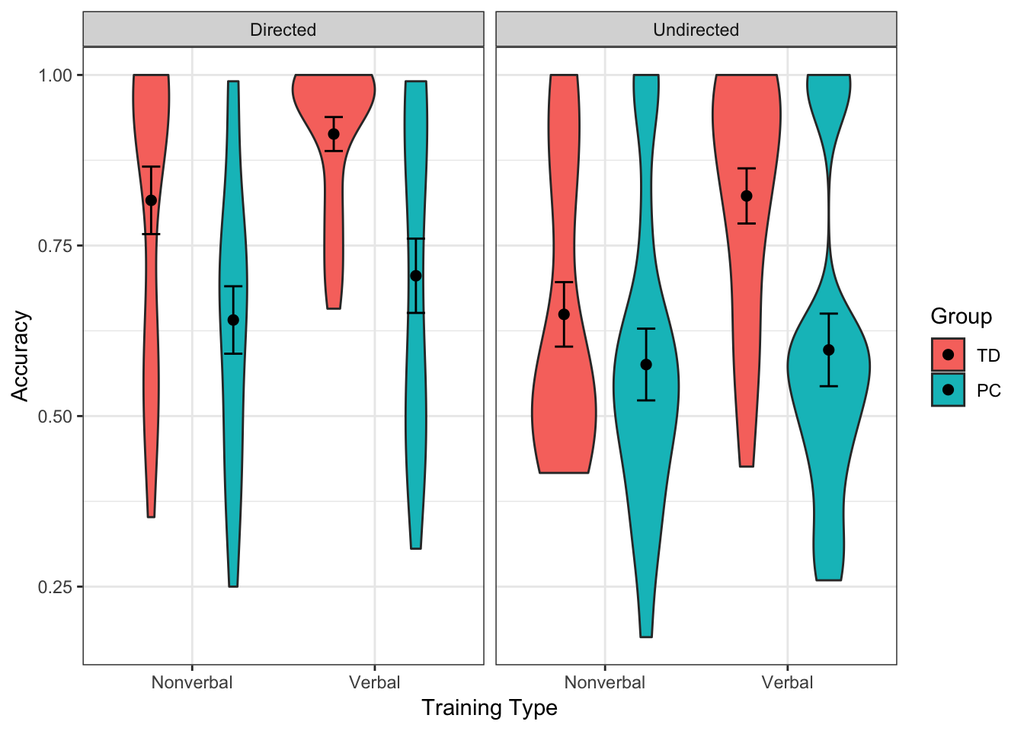

```r
acc_summary1 <- summarySE(data = acc_group, "Acc", groupvars = c("train.type", "Group", "info.type"))
p1 <- ggplot(acc_group, aes(info.type, Acc, fill = Group)) + geom_violin() +
  xlab("Training Type") + ylab("Accuracy")  +
  facet_grid(.~train.type) +
  geom_point(aes(y = Acc), size = 2, position = position_dodge((width = 0.90)), data = acc_summary1) +
  geom_errorbar(aes(ymin = Acc-se, ymax = Acc+se),
                width = 0.20, position = position_dodge((width = 0.90)), data = acc_summary1) + theme_bw()
p1
```

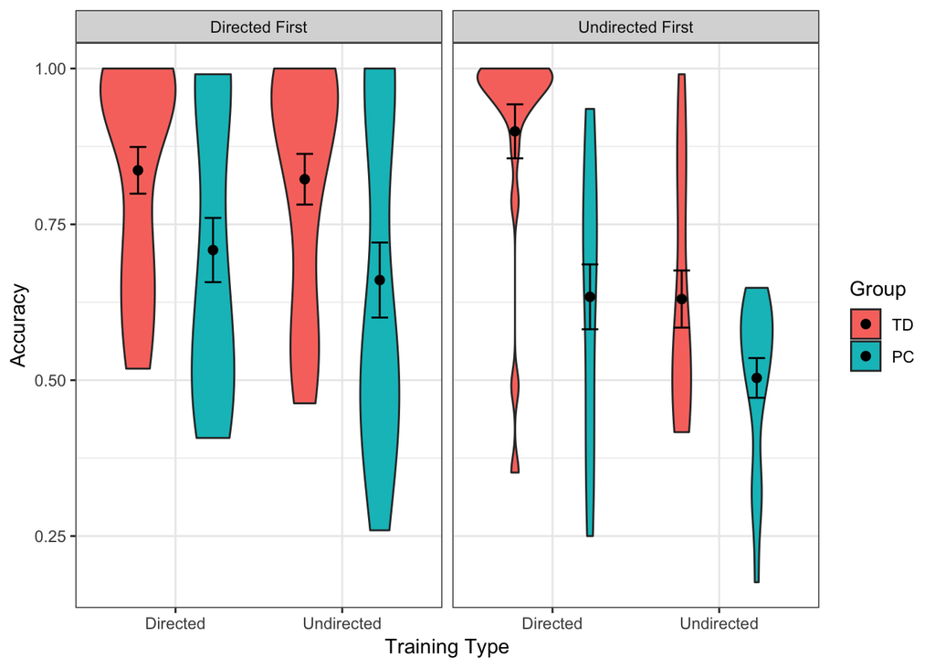

```r
acc_summary2 <- summarySE(data = acc_group, "Acc", groupvars = c("train.type", "Group", "Order"))
p2 <- ggplot(acc_group, aes(train.type, Acc, fill = Group)) + geom_violin() +
  xlab("Training Type") + ylab("Accuracy")  +
  facet_grid(.~Order) +
  geom_point(aes(y = Acc), size = 2, position = position_dodge((width = 0.90)), data = acc_summary2) +
  geom_errorbar(aes(ymin = Acc-se, ymax = Acc+se),
                width = 0.20, position = position_dodge((width = 0.90)), data = acc_summary2) + theme_bw()
p2
```

# Continuous Analysis

## Linear Mixed-Effects Models

### Standard Analysis

```r
acc_beh$acc.logit <- car::logit(acc_beh$Acc)

# base model
m0 <- lme(acc.logit ~ 1, random = ~1|Subj, data = acc_beh, method = "ML")
summary(m0)
```

```
## Linear mixed-effects model fit by maximum likelihood
##  Data: acc_beh
##        AIC     BIC    logLik
##   614.9412 624.586 -304.4706
##
## Random effects:
##  Formula: ~1 | Subj
##         (Intercept) Residual
## StdDev:    1.043025 1.033272
##
## Fixed effects: acc.logit ~ 1
##                Value Std.Error  DF  t-value p-value
## (Intercept) 1.375768 0.1720856 138 7.994675       0
##
## Standardized Within-Group Residuals:
##         Min          Q1         Med          Q3         Max
## -2.30071311 -0.55892441 -0.06396818  0.55626204  2.14075704
##
## Number of Observations: 184
## Number of Groups: 46
```

```r
# adding in task conditions
m0.0 <- lme(acc.logit ~ train.type + info.type, random = ~1|Subj, data = acc_beh, method = "ML")
anova(m0,m0.0)
```

```
##      Model df      AIC      BIC    logLik   Test  L.Ratio p-value
## m0       1  3 614.9412 624.5860 -304.4706
## m0.0     2  5 565.0608 581.1355 -277.5304 1 vs 2 53.88047  <.0001
```

```r
# adding in individual difference measures
m0.5 <- lme(acc.logit ~ P_IQ + WA_SS, random = ~1|Subj, data = acc_beh, method = "ML")
# full model
m1 <- lme(acc.logit ~ P_IQ + WA_SS + KTEA_SS * train.type * info.type, random = ~1|Subj, data = acc_beh, method = "ML")
summary(m1)
```

```
## Linear mixed-effects model fit by maximum likelihood
##  Data: acc_beh
##        AIC      BIC    logLik
##   560.0551 598.6343 -268.0275
##
## Random effects:
##  Formula: ~1 | Subj
##         (Intercept)  Residual
## StdDev:   0.9318191 0.8291919
##
## Fixed effects: acc.logit ~ P_IQ + WA_SS + KTEA_SS * train.type * info.type
##                                                  Value Std.Error  DF
## (Intercept)                                  -5.903591 2.3850928 132
## P_IQ                                          0.006200 0.0179290  42
## WA_SS                                         0.040330 0.0233614  42
## KTEA_SS                                       0.026714 0.0186607  42
## train.typeUndirected                          1.526079 1.1921267 132
## info.typeVerbal                               0.350692 1.1921267 132
## KTEA_SS:train.typeUndirected                 -0.025074 0.0120125 132
## KTEA_SS:info.typeVerbal                       0.001202 0.0120125 132
## train.typeUndirected:info.typeVerbal         -1.844699 1.6859218 132
## KTEA_SS:train.typeUndirected:info.typeVerbal  0.020292 0.0169883 132
##                                                 t-value p-value
## (Intercept)                                  -2.4752040  0.0146
## P_IQ                                          0.3458039  0.7312
## WA_SS                                         1.7263365  0.0916
## KTEA_SS                                       1.4315555  0.1597
## train.typeUndirected                          1.2801312  0.2027
## info.typeVerbal                               0.2941733  0.7691
## KTEA_SS:train.typeUndirected                 -2.0873389  0.0388
## KTEA_SS:info.typeVerbal                       0.1000733  0.9204
## train.typeUndirected:info.typeVerbal         -1.0941781  0.2759
## KTEA_SS:train.typeUndirected:info.typeVerbal  1.1944877  0.2344
##  Correlation:
##                                              (Intr) P_IQ   WA_SS  KTEA_SS
## P_IQ                                         -0.247
## WA_SS                                        -0.805 -0.022
## KTEA_SS                                       0.029 -0.675 -0.260
## train.typeUndirected                         -0.250  0.000  0.000  0.318
## info.typeVerbal                              -0.250  0.000  0.000  0.318
```

[output cut: 16 more lines]

```
## WA_SS
## KTEA_SS
## train.typeUndirected
## info.typeVerbal
## KTEA_SS:train.typeUndirected
## KTEA_SS:info.typeVerbal
## train.typeUndirected:info.typeVerbal          0.699
## KTEA_SS:train.typeUndirected:info.typeVerbal -0.707     -0.989
##
## Standardized Within-Group Residuals:
##         Min          Q1         Med          Q3         Max
## -1.97220783 -0.68441712 -0.01637841  0.59661085  2.15859085
##
## Number of Observations: 184
## Number of Groups: 46
```

```r
anova(m0.5,m1)
```

```
##      Model df      AIC      BIC    logLik   Test L.Ratio p-value
## m0.5     1  5 608.1801 624.2548 -299.0900
## m1       2 12 560.0551 598.6343 -268.0275 1 vs 2  62.125  <.0001
```

### Order Analysis

```r
m2 <- lme(acc.logit ~ P_IQ + WA_SS + KTEA_SS * Order * train.type * info.type, random = ~1|Subj, data = acc_beh, method = "ML")
summary(m2)
```

```
## Linear mixed-effects model fit by maximum likelihood
##  Data: acc_beh
##        AIC      BIC    logLik
##   540.2542 604.5529 -250.1271
##
## Random effects:
##  Formula: ~1 | Subj
##         (Intercept)  Residual
## StdDev:   0.9022837 0.7393111
##
## Fixed effects: acc.logit ~ P_IQ + WA_SS + KTEA_SS * Order * train.type * info.type
##                                                                        Value
## (Intercept)                                                        -4.304064
## P_IQ                                                                0.008264
## WA_SS                                                               0.040175
## KTEA_SS                                                             0.008344
## OrderUndirected First                                              -3.536988
## train.typeUndirected                                               -0.475705
## info.typeVerbal                                                    -0.640438
## KTEA_SS:OrderUndirected First                                       0.035674
## KTEA_SS:train.typeUndirected                                        0.000891
## OrderUndirected First:train.typeUndirected                          3.612329
## KTEA_SS:info.typeVerbal                                             0.011025
## OrderUndirected First:info.typeVerbal                               2.147590
## train.typeUndirected:info.typeVerbal                               -0.270950
## KTEA_SS:OrderUndirected First:train.typeUndirected                 -0.048411
## KTEA_SS:OrderUndirected First:info.typeVerbal                      -0.021021
## KTEA_SS:train.typeUndirected:info.typeVerbal                        0.004537
## OrderUndirected First:train.typeUndirected:info.typeVerbal         -3.391421
## KTEA_SS:OrderUndirected First:train.typeUndirected:info.typeVerbal  0.033531
##                                                                    Std.Error
## (Intercept)                                                        2.7023992
## P_IQ                                                               0.0177425
## WA_SS                                                              0.0232701
## KTEA_SS                                                            0.0221024
## OrderUndirected First                                              2.4853564
## train.typeUndirected                                               1.4930924
## info.typeVerbal                                                    1.4930924
## KTEA_SS:OrderUndirected First                                      0.0250235
## KTEA_SS:train.typeUndirected                                       0.0152056
```

[output cut: 365 more lines]

```
## KTEA_SS:info.typeVerbal
## OrderUndirected First:info.typeVerbal
## train.typeUndirected:info.typeVerbal
## KTEA_SS:OrderUndirected First:train.typeUndirected
## KTEA_SS:OrderUndirected First:info.typeVerbal
## KTEA_SS:train.typeUndirected:info.typeVerbal
## OrderUndirected First:train.typeUndirected:info.typeVerbal
## KTEA_SS:OrderUndirected First:train.typeUndirected:info.typeVerbal -0.989
##
## Standardized Within-Group Residuals:
##          Min           Q1          Med           Q3          Max
## -2.572055018 -0.587995258  0.002399288  0.576033346  2.364343291
##
## Number of Observations: 184
## Number of Groups: 46
```

```r
anova(m1,m2)
```

```
##    Model df      AIC      BIC    logLik   Test  L.Ratio p-value
## m1     1 12 560.0551 598.6343 -268.0275
## m2     2 20 540.2542 604.5529 -250.1271 1 vs 2 35.80089  <.0001
```

```r
dirfSubset <- acc_beh$Order=="Directed First"
undirfSubset <- acc_beh$Order=="Undirected First"
dirfModel <- lme(acc.logit ~ P_IQ + WA_SS + KTEA_SS * train.type * info.type, random = ~1|Subj, data = acc_beh, subset = dirfSubset, method = "ML")
summary(dirfModel)
```

```
## Linear mixed-effects model fit by maximum likelihood
##  Data: acc_beh
##   Subset: dirfSubset
##        AIC      BIC    logLik
##   287.7657 319.0277 -131.8828
##
## Random effects:
##  Formula: ~1 | Subj
##         (Intercept)  Residual
## StdDev:    1.003017 0.6813165
##
## Fixed effects: acc.logit ~ P_IQ + WA_SS + KTEA_SS * train.type * info.type
##                                                   Value Std.Error DF
## (Intercept)                                  -11.266044  4.540860 69
## P_IQ                                           0.041129  0.030495 21
## WA_SS                                          0.107484  0.041826 21
## KTEA_SS                                       -0.027036  0.032311 21
## train.typeUndirected                          -0.475705  1.377629 69
## info.typeVerbal                               -0.640438  1.377629 69
## KTEA_SS:train.typeUndirected                   0.000891  0.014030 69
## KTEA_SS:info.typeVerbal                        0.011025  0.014030 69
## train.typeUndirected:info.typeVerbal          -0.270950  1.948262 69
## KTEA_SS:train.typeUndirected:info.typeVerbal   0.004537  0.019841 69
##                                                 t-value p-value
## (Intercept)                                  -2.4810377  0.0155
## P_IQ                                          1.3487061  0.1918
## WA_SS                                         2.5697950  0.0179
## KTEA_SS                                      -0.8367382  0.4122
## train.typeUndirected                         -0.3453071  0.7309
## info.typeVerbal                              -0.4648844  0.6435
## KTEA_SS:train.typeUndirected                  0.0635213  0.9495
## KTEA_SS:info.typeVerbal                       0.7858638  0.4346
## train.typeUndirected:info.typeVerbal         -0.1390727  0.8898
## KTEA_SS:train.typeUndirected:info.typeVerbal  0.2286861  0.8198
##  Correlation:
##                                              (Intr) P_IQ   WA_SS  KTEA_SS
## P_IQ                                         -0.545
## WA_SS                                        -0.909  0.434
## KTEA_SS                                       0.365 -0.821 -0.506
## train.typeUndirected                         -0.152  0.000  0.000  0.215
```

[output cut: 17 more lines]

```
## WA_SS
## KTEA_SS
## train.typeUndirected
## info.typeVerbal
## KTEA_SS:train.typeUndirected
## KTEA_SS:info.typeVerbal
## train.typeUndirected:info.typeVerbal          0.699
## KTEA_SS:train.typeUndirected:info.typeVerbal -0.707     -0.989
##
## Standardized Within-Group Residuals:
##         Min          Q1         Med          Q3         Max
## -2.07796527 -0.58288654 -0.08523717  0.56883748  2.51809879
##
## Number of Observations: 100
## Number of Groups: 25
```

```r
undirfModel <- lme(acc.logit ~ P_IQ + WA_SS + KTEA_SS * train.type * info.type, random = ~1|Subj, data = acc_beh, subset = undirfSubset, method = "ML")
summary(undirfModel)
```

```
## Linear mixed-effects model fit by maximum likelihood
##  Data: acc_beh
##   Subset: undirfSubset
##        AIC      BIC    logLik
##   249.4128 278.5826 -112.7064
##
## Random effects:
##  Formula: ~1 | Subj
##         (Intercept)  Residual
## StdDev:   0.5848364 0.8029079
##
## Fixed effects: acc.logit ~ P_IQ + WA_SS + KTEA_SS * train.type * info.type
##                                                  Value Std.Error DF
## (Intercept)                                  -4.908606 2.3140986 57
## P_IQ                                          0.012778 0.0208033 17
## WA_SS                                        -0.001613 0.0262183 17
## KTEA_SS                                       0.053779 0.0191681 17
## train.typeUndirected                          3.136624 1.7579572 57
## info.typeVerbal                               1.507152 1.7579572 57
## KTEA_SS:train.typeUndirected                 -0.047519 0.0174969 57
## KTEA_SS:info.typeVerbal                      -0.009996 0.0174969 57
## train.typeUndirected:info.typeVerbal         -3.662371 2.4861270 57
## KTEA_SS:train.typeUndirected:info.typeVerbal  0.038068 0.0247443 57
##                                                 t-value p-value
## (Intercept)                                  -2.1211741  0.0383
## P_IQ                                          0.6142184  0.5472
## WA_SS                                        -0.0615366  0.9516
## KTEA_SS                                       2.8056327  0.0122
## train.typeUndirected                          1.7842436  0.0797
## info.typeVerbal                               0.8573314  0.3949
## KTEA_SS:train.typeUndirected                 -2.7158838  0.0087
## KTEA_SS:info.typeVerbal                      -0.5712809  0.5701
## train.typeUndirected:info.typeVerbal         -1.4731231  0.1462
## KTEA_SS:train.typeUndirected:info.typeVerbal  1.5384574  0.1295
##  Correlation:
##                                              (Intr) P_IQ   WA_SS  KTEA_SS
## P_IQ                                          0.007
## WA_SS                                        -0.661 -0.475
## KTEA_SS                                      -0.258 -0.481 -0.091
## train.typeUndirected                         -0.380  0.000  0.000  0.451
```

[output cut: 17 more lines]

```
## WA_SS
## KTEA_SS
## train.typeUndirected
## info.typeVerbal
## KTEA_SS:train.typeUndirected
## KTEA_SS:info.typeVerbal
## train.typeUndirected:info.typeVerbal          0.699
## KTEA_SS:train.typeUndirected:info.typeVerbal -0.707     -0.989
##
## Standardized Within-Group Residuals:
##         Min          Q1         Med          Q3         Max
## -2.59750767 -0.54796581  0.07366354  0.58448211  1.99654561
##
## Number of Observations: 84
## Number of Groups: 21
```

## Plots

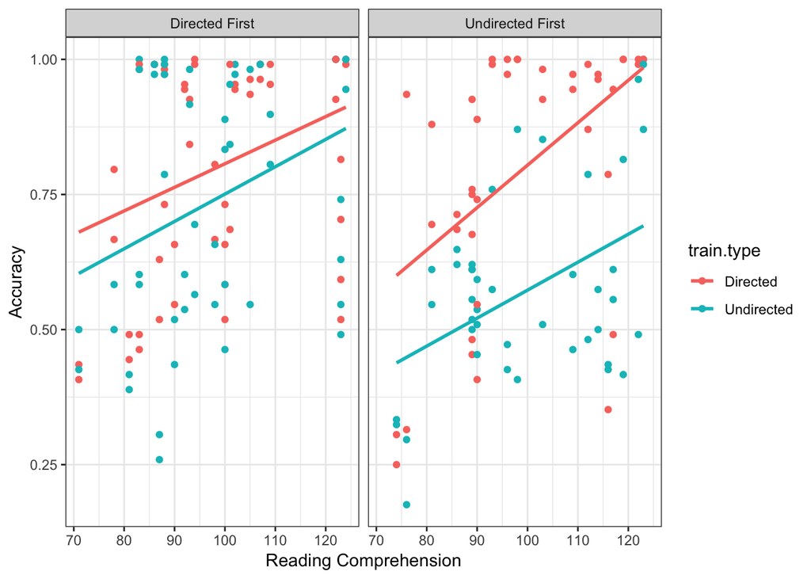

```r
p2 <- ggplot(acc_beh, aes(KTEA_SS, Acc, color = train.type)) + geom_point() +
  xlab("Reading Comprehension") + ylab("Accuracy")  +
  facet_grid(.~Order) + theme_bw() + geom_smooth(method = "lm", se = FALSE)
p2
```

# Misc Analyses

## Reliability

```r
reliability <- dat3[,c(1,2,3,7)]
rel <- cast(reliability, Subj ~ condition, sum, value = "Acc")
alpha(rel[,-1])
```

```
##
## Reliability analysis
## Call: alpha(x = rel[, -1])
##
##   raw_alpha std.alpha G6(smc) average_r S/N   ase mean sd median_r
##       0.86      0.86    0.87      0.61 6.3 0.034   79 20     0.61
##
##  lower alpha upper     95% confidence boundaries
## 0.8 0.86 0.93
##
##  Reliability if an item is dropped:
##                    raw_alpha std.alpha G6(smc) average_r S/N alpha se
## Explicit_Nonverbal      0.82      0.81    0.79      0.59 4.4    0.047
## Explicit_Verbal         0.84      0.84    0.80      0.63 5.1    0.043
## Implicit_Nonverbal      0.85      0.85    0.81      0.66 5.9    0.038
## Implicit_Verbal         0.79      0.79    0.76      0.56 3.9    0.053
##                     var.r med.r
## Explicit_Nonverbal 0.0285  0.59
## Explicit_Verbal    0.0168  0.63
## Implicit_Nonverbal 0.0079  0.63
## Implicit_Verbal    0.0314  0.50
##
##  Item statistics
##                     n raw.r std.r r.cor r.drop mean sd
## Explicit_Nonverbal 46  0.86  0.86  0.81   0.74   82 25
## Explicit_Verbal    46  0.82  0.83  0.76   0.69   90 22
## Implicit_Nonverbal 46  0.80  0.80  0.72   0.64   65 23
## Implicit_Verbal    46  0.89  0.89  0.85   0.79   77 24
```

```r
rel_ENV <- cast(subset(reliability, condition == "Explicit_Nonverbal"), Subj ~ condition + Trial, sum, value = "Acc")
rel_EV <- cast(subset(reliability, condition == "Explicit_Verbal"), Subj ~ condition + Trial, sum, value = "Acc")
rel_INV <- cast(subset(reliability, condition == "Implicit_Nonverbal"), Subj ~ condition + Trial, sum, value = "Acc")
rel_IV <- cast(subset(reliability, condition == "Implicit_Verbal"), Subj ~ condition + Trial, sum, value = "Acc")
alpha(rel_ENV[,-1])
```

```
##
## Reliability analysis
## Call: alpha(x = rel_ENV[, -1])
##
##   raw_alpha std.alpha G6(smc) average_r S/N    ase mean   sd median_r
##       0.98      0.98       1      0.28  41 0.0048 0.76 0.23     0.28
##
##  lower alpha upper     95% confidence boundaries
## 0.97 0.98 0.99
##
##  Reliability if an item is dropped:
##                        raw_alpha std.alpha G6(smc) average_r S/N var.r
## Explicit_Nonverbal_1        0.98      0.98       1      0.28  42 0.024
## Explicit_Nonverbal_2        0.98      0.98       1      0.28  41 0.024
## Explicit_Nonverbal_3        0.98      0.98       1      0.28  41 0.024
## Explicit_Nonverbal_4        0.98      0.98       1      0.28  41 0.024
## Explicit_Nonverbal_5        0.98      0.98       1      0.28  41 0.024
## Explicit_Nonverbal_6        0.98      0.98       1      0.28  41 0.024
## Explicit_Nonverbal_7        0.98      0.98       1      0.28  41 0.024
## Explicit_Nonverbal_8        0.98      0.98       1      0.28  42 0.024
## Explicit_Nonverbal_9        0.98      0.98       1      0.28  41 0.024
## Explicit_Nonverbal_10       0.98      0.98       1      0.28  41 0.024
## Explicit_Nonverbal_11       0.98      0.98       1      0.28  41 0.024
## Explicit_Nonverbal_12       0.98      0.98       1      0.28  41 0.024
## Explicit_Nonverbal_13       0.98      0.98       1      0.28  41 0.024
## Explicit_Nonverbal_14       0.98      0.98       1      0.28  42 0.024
## Explicit_Nonverbal_15       0.98      0.98       1      0.28  41 0.024
## Explicit_Nonverbal_16       0.98      0.98       1      0.28  41 0.024
## Explicit_Nonverbal_17       0.98      0.98       1      0.28  41 0.024
## Explicit_Nonverbal_18       0.98      0.98       1      0.28  41 0.024
## Explicit_Nonverbal_19       0.98      0.98       1      0.28  41 0.024
## Explicit_Nonverbal_20       0.98      0.98       1      0.28  41 0.024
## Explicit_Nonverbal_21       0.98      0.98       1      0.28  41 0.024
## Explicit_Nonverbal_22       0.98      0.98       1      0.28  41 0.024
## Explicit_Nonverbal_23       0.98      0.98       1      0.28  41 0.024
## Explicit_Nonverbal_24       0.98      0.98       1      0.28  41 0.024
## Explicit_Nonverbal_25       0.98      0.98       1      0.28  41 0.024
## Explicit_Nonverbal_26       0.98      0.98       1      0.28  41 0.024
## Explicit_Nonverbal_27       0.98      0.98       1      0.28  41 0.024
## Explicit_Nonverbal_28       0.98      0.98       1      0.28  41 0.024
```

[output cut: 396 more lines]

```
## Explicit_Nonverbal_94  0.17 0.83    0
## Explicit_Nonverbal_95  0.20 0.80    0
## Explicit_Nonverbal_96  0.24 0.76    0
## Explicit_Nonverbal_97  0.26 0.74    0
## Explicit_Nonverbal_98  0.22 0.78    0
## Explicit_Nonverbal_99  0.22 0.78    0
## Explicit_Nonverbal_100 0.13 0.87    0
## Explicit_Nonverbal_101 0.30 0.70    0
## Explicit_Nonverbal_102 0.28 0.72    0
## Explicit_Nonverbal_103 0.24 0.76    0
## Explicit_Nonverbal_104 0.15 0.85    0
## Explicit_Nonverbal_105 0.17 0.83    0
## Explicit_Nonverbal_106 0.17 0.83    0
## Explicit_Nonverbal_107 0.26 0.74    0
## Explicit_Nonverbal_108 0.22 0.78    0
```

```r
alpha(rel_EV[,-1])
```

```
##
## Reliability analysis
## Call: alpha(x = rel_EV[, -1])
##
##   raw_alpha std.alpha G6(smc) average_r S/N    ase mean  sd median_r
##       0.98      0.98       1      0.28  42 0.0047 0.83 0.2     0.28
##
##  lower alpha upper     95% confidence boundaries
## 0.97 0.98 0.99
##
##  Reliability if an item is dropped:
##                     raw_alpha std.alpha G6(smc) average_r S/N var.r med.r
## Explicit_Verbal_1        0.98      0.98       1      0.28  42 0.031  0.28
## Explicit_Verbal_2        0.98      0.98       1      0.28  42 0.032  0.28
## Explicit_Verbal_3        0.98      0.98       1      0.28  42 0.031  0.28
## Explicit_Verbal_4        0.98      0.98       1      0.28  42 0.031  0.28
## Explicit_Verbal_5        0.98      0.98       1      0.28  42 0.031  0.28
## Explicit_Verbal_6        0.98      0.98       1      0.28  42 0.031  0.28
## Explicit_Verbal_7        0.98      0.98       1      0.28  42 0.031  0.28
## Explicit_Verbal_8        0.98      0.98       1      0.28  42 0.031  0.28
## Explicit_Verbal_9        0.98      0.98       1      0.28  41 0.031  0.28
## Explicit_Verbal_10       0.98      0.98       1      0.28  42 0.032  0.28
## Explicit_Verbal_11       0.98      0.98       1      0.28  42 0.031  0.28
## Explicit_Verbal_12       0.98      0.98       1      0.28  42 0.031  0.28
## Explicit_Verbal_13       0.98      0.98       1      0.28  42 0.031  0.28
## Explicit_Verbal_14       0.98      0.98       1      0.28  41 0.031  0.28
## Explicit_Verbal_15       0.98      0.98       1      0.28  41 0.031  0.28
## Explicit_Verbal_16       0.98      0.98       1      0.28  42 0.032  0.28
## Explicit_Verbal_17       0.98      0.98       1      0.28  41 0.031  0.28
## Explicit_Verbal_18       0.98      0.98       1      0.28  42 0.031  0.28
## Explicit_Verbal_19       0.98      0.98       1      0.28  41 0.031  0.28
## Explicit_Verbal_20       0.98      0.98       1      0.28  41 0.031  0.28
## Explicit_Verbal_21       0.98      0.98       1      0.28  42 0.031  0.28
## Explicit_Verbal_22       0.98      0.98       1      0.28  42 0.032  0.28
## Explicit_Verbal_23       0.98      0.98       1      0.28  42 0.031  0.28
## Explicit_Verbal_24       0.98      0.98       1      0.28  42 0.032  0.28
## Explicit_Verbal_25       0.98      0.98       1      0.28  42 0.031  0.28
## Explicit_Verbal_26       0.98      0.98       1      0.28  41 0.031  0.28
## Explicit_Verbal_27       0.98      0.98       1      0.28  42 0.031  0.28
## Explicit_Verbal_28       0.98      0.98       1      0.28  42 0.032  0.28
```

[output cut: 287 more lines]

```
## Explicit_Verbal_94  0.13 0.87    0
## Explicit_Verbal_95  0.22 0.78    0
## Explicit_Verbal_96  0.24 0.76    0
## Explicit_Verbal_97  0.17 0.83    0
## Explicit_Verbal_98  0.17 0.83    0
## Explicit_Verbal_99  0.20 0.80    0
## Explicit_Verbal_100 0.22 0.78    0
## Explicit_Verbal_101 0.11 0.89    0
## Explicit_Verbal_102 0.20 0.80    0
## Explicit_Verbal_103 0.11 0.89    0
## Explicit_Verbal_104 0.09 0.91    0
## Explicit_Verbal_105 0.17 0.83    0
## Explicit_Verbal_106 0.11 0.89    0
## Explicit_Verbal_107 0.13 0.87    0
## Explicit_Verbal_108 0.17 0.83    0
```

```r
alpha(rel_IV[,-1])
```

```
##
## Reliability analysis
## Call: alpha(x = rel_IV[, -1])
##
##   raw_alpha std.alpha G6(smc) average_r S/N   ase mean   sd median_r
##       0.97      0.97       1      0.24  33 0.006 0.71 0.22     0.24
##
##  lower alpha upper     95% confidence boundaries
## 0.96 0.97 0.98
##
##  Reliability if an item is dropped:
##                     raw_alpha std.alpha G6(smc) average_r S/N var.r med.r
## Implicit_Verbal_1        0.97      0.97       1      0.24  33 0.023  0.24
## Implicit_Verbal_2        0.97      0.97       1      0.24  33 0.023  0.24
## Implicit_Verbal_3        0.97      0.97       1      0.24  33 0.023  0.24
## Implicit_Verbal_4        0.97      0.97       1      0.24  33 0.023  0.24
## Implicit_Verbal_5        0.97      0.97       1      0.23  33 0.023  0.24
## Implicit_Verbal_6        0.97      0.97       1      0.24  33 0.023  0.24
## Implicit_Verbal_7        0.97      0.97       1      0.24  33 0.023  0.24
## Implicit_Verbal_8        0.97      0.97       1      0.24  33 0.023  0.24
## Implicit_Verbal_9        0.97      0.97       1      0.24  33 0.023  0.24
## Implicit_Verbal_10       0.97      0.97       1      0.23  33 0.023  0.24
## Implicit_Verbal_11       0.97      0.97       1      0.24  33 0.023  0.24
## Implicit_Verbal_12       0.97      0.97       1      0.24  33 0.023  0.24
## Implicit_Verbal_13       0.97      0.97       1      0.24  33 0.023  0.24
## Implicit_Verbal_14       0.97      0.97       1      0.24  33 0.023  0.24
## Implicit_Verbal_15       0.97      0.97       1      0.24  33 0.023  0.24
## Implicit_Verbal_16       0.97      0.97       1      0.24  34 0.022  0.24
## Implicit_Verbal_17       0.97      0.97       1      0.24  33 0.023  0.24
## Implicit_Verbal_18       0.97      0.97       1      0.24  33 0.023  0.24
## Implicit_Verbal_19       0.97      0.97       1      0.24  33 0.023  0.24
## Implicit_Verbal_20       0.97      0.97       1      0.24  33 0.023  0.24
## Implicit_Verbal_21       0.97      0.97       1      0.24  33 0.023  0.24
## Implicit_Verbal_22       0.97      0.97       1      0.23  33 0.023  0.24
## Implicit_Verbal_23       0.97      0.97       1      0.24  33 0.023  0.24
## Implicit_Verbal_24       0.97      0.97       1      0.24  33 0.023  0.24
## Implicit_Verbal_25       0.97      0.97       1      0.24  33 0.023  0.24
## Implicit_Verbal_26       0.97      0.97       1      0.24  33 0.023  0.24
## Implicit_Verbal_27       0.97      0.97       1      0.24  33 0.023  0.24
## Implicit_Verbal_28       0.97      0.97       1      0.24  33 0.023  0.24
```

[output cut: 287 more lines]

```
## Implicit_Verbal_94  0.20 0.80    0
## Implicit_Verbal_95  0.22 0.78    0
## Implicit_Verbal_96  0.15 0.85    0
## Implicit_Verbal_97  0.24 0.76    0
## Implicit_Verbal_98  0.30 0.70    0
## Implicit_Verbal_99  0.24 0.76    0
## Implicit_Verbal_100 0.35 0.65    0
## Implicit_Verbal_101 0.28 0.72    0
## Implicit_Verbal_102 0.35 0.65    0
## Implicit_Verbal_103 0.30 0.70    0
## Implicit_Verbal_104 0.30 0.70    0
## Implicit_Verbal_105 0.30 0.70    0
## Implicit_Verbal_106 0.20 0.80    0
## Implicit_Verbal_107 0.20 0.80    0
## Implicit_Verbal_108 0.30 0.70    0
```

```r
alpha(rel_INV[,-1])
```

```
##
## Reliability analysis
## Call: alpha(x = rel_INV[, -1])
##
##   raw_alpha std.alpha G6(smc) average_r S/N    ase mean   sd median_r
##       0.96      0.96       1      0.18  24 0.0085 0.61 0.21     0.18
##
##  lower alpha upper     95% confidence boundaries
## 0.94 0.96 0.98
##
##  Reliability if an item is dropped:
##                        raw_alpha std.alpha G6(smc) average_r S/N var.r
## Implicit_Nonverbal_1        0.96      0.96       1      0.18  24  0.02
## Implicit_Nonverbal_2        0.96      0.96       1      0.18  24  0.02
## Implicit_Nonverbal_3        0.96      0.96       1      0.18  24  0.02
## Implicit_Nonverbal_4        0.96      0.96       1      0.18  23  0.02
## Implicit_Nonverbal_5        0.96      0.96       1      0.18  23  0.02
## Implicit_Nonverbal_6        0.96      0.96       1      0.18  23  0.02
## Implicit_Nonverbal_7        0.96      0.96       1      0.18  24  0.02
## Implicit_Nonverbal_8        0.96      0.96       1      0.18  24  0.02
## Implicit_Nonverbal_9        0.96      0.96       1      0.18  24  0.02
## Implicit_Nonverbal_10       0.96      0.96       1      0.18  23  0.02
## Implicit_Nonverbal_11       0.96      0.96       1      0.18  24  0.02
## Implicit_Nonverbal_12       0.96      0.96       1      0.18  24  0.02
## Implicit_Nonverbal_13       0.96      0.96       1      0.18  24  0.02
## Implicit_Nonverbal_14       0.96      0.96       1      0.18  23  0.02
## Implicit_Nonverbal_15       0.96      0.96       1      0.18  24  0.02
## Implicit_Nonverbal_16       0.96      0.96       1      0.18  24  0.02
## Implicit_Nonverbal_17       0.96      0.96       1      0.18  24  0.02
## Implicit_Nonverbal_18       0.96      0.96       1      0.18  24  0.02
## Implicit_Nonverbal_19       0.96      0.96       1      0.18  24  0.02
## Implicit_Nonverbal_20       0.96      0.96       1      0.18  24  0.02
## Implicit_Nonverbal_21       0.96      0.96       1      0.18  24  0.02
## Implicit_Nonverbal_22       0.96      0.96       1      0.18  24  0.02
## Implicit_Nonverbal_23       0.96      0.96       1      0.18  23  0.02
## Implicit_Nonverbal_24       0.96      0.96       1      0.18  24  0.02
## Implicit_Nonverbal_25       0.96      0.96       1      0.18  23  0.02
## Implicit_Nonverbal_26       0.96      0.96       1      0.18  23  0.02
## Implicit_Nonverbal_27       0.96      0.96       1      0.18  23  0.02
## Implicit_Nonverbal_28       0.96      0.96       1      0.18  23  0.02
```

[output cut: 396 more lines]

```
## Implicit_Nonverbal_94  0.33 0.67    0
## Implicit_Nonverbal_95  0.33 0.67    0
## Implicit_Nonverbal_96  0.33 0.67    0
## Implicit_Nonverbal_97  0.41 0.59    0
## Implicit_Nonverbal_98  0.46 0.54    0
## Implicit_Nonverbal_99  0.39 0.61    0
## Implicit_Nonverbal_100 0.35 0.65    0
## Implicit_Nonverbal_101 0.48 0.52    0
## Implicit_Nonverbal_102 0.30 0.70    0
## Implicit_Nonverbal_103 0.26 0.74    0
## Implicit_Nonverbal_104 0.37 0.63    0
## Implicit_Nonverbal_105 0.39 0.61    0
## Implicit_Nonverbal_106 0.28 0.72    0
## Implicit_Nonverbal_107 0.35 0.65    0
## Implicit_Nonverbal_108 0.41 0.59    0
```

## Ceiling Effects

```r
ENV <- subset(acc_group, Cond == "Explicit_Nonverbal")
EV <- subset(acc_group, Cond == "Explicit_Verbal")
INV <- subset(acc_group, Cond == "Implicit_Nonverbal")
IV <- subset(acc_group, Cond == "Implicit_Verbal")

dagoTest(ENV$Acc)
```

```
##
## Title:
##  D'Agostino Normality Test
##
## Test Results:
##   STATISTIC:
##     Chi2 | Omnibus: 8.2245
##     Z3  | Skewness: -0.9173
##     Z4  | Kurtosis: -2.7172
##   P VALUE:
##     Omnibus  Test: 0.01637
##     Skewness Test: 0.359
##     Kurtosis Test: 0.006584
##
## Description:
##  Thu Oct 11 17:36:06 2018 by user:
```

```r
dagoTest(EV$Acc)
```

```
##
## Title:
##  D'Agostino Normality Test
##
## Test Results:
##   STATISTIC:
##     Chi2 | Omnibus: 5.9944
##     Z3  | Skewness: -2.3873
##     Z4  | Kurtosis: -0.5434
##   P VALUE:
##     Omnibus  Test: 0.04993
##     Skewness Test: 0.01697
##     Kurtosis Test: 0.5868
##
## Description:
##  Thu Oct 11 17:36:06 2018 by user:
```

```r
dagoTest(INV$Acc)
```

```
##
## Title:
##  D'Agostino Normality Test
##
## Test Results:
##   STATISTIC:
##     Chi2 | Omnibus: 2.8584
##     Z3  | Skewness: 1.4136
##     Z4  | Kurtosis: -0.9274
##   P VALUE:
##     Omnibus  Test: 0.2395
##     Skewness Test: 0.1575
##     Kurtosis Test: 0.3537
##
## Description:
##  Thu Oct 11 17:36:06 2018 by user:
```

```r
dagoTest(IV$Acc)
```

```
##
## Title:
##  D'Agostino Normality Test
##
## Test Results:
##   STATISTIC:
##     Chi2 | Omnibus: 10.8364
##     Z3  | Skewness: -0.5021
##     Z4  | Kurtosis: -3.2534
##   P VALUE:
##     Omnibus  Test: 0.004435
##     Skewness Test: 0.6156
##     Kurtosis Test: 0.001141
##
## Description:
##  Thu Oct 11 17:36:06 2018 by user:
```

```r
EV_high <- subset(EV, Acc > 0.95)
table(EV_high$Group)
```

```
##
## TD PC
## 12  4
```

## Verbal IQ

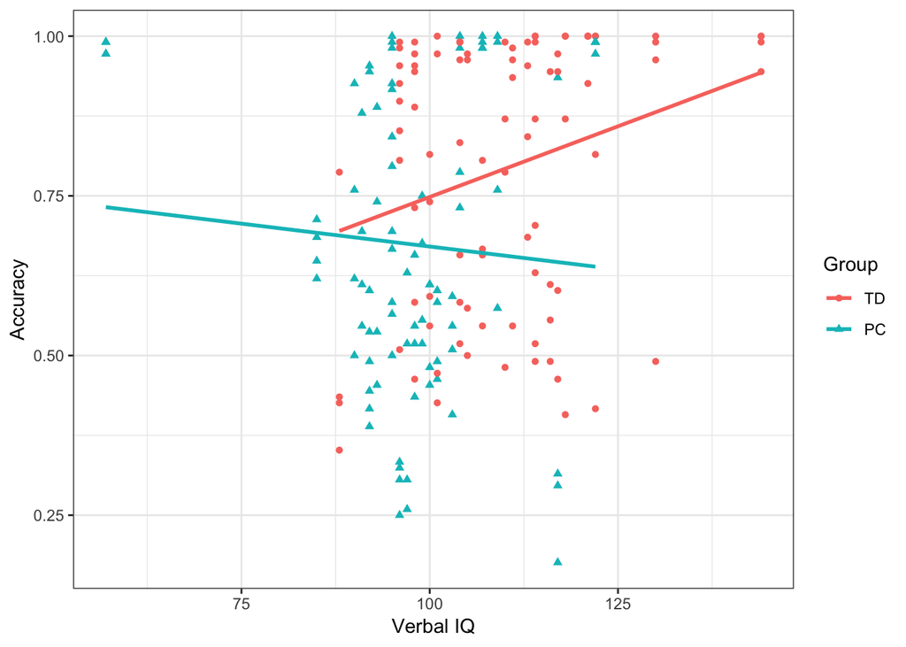

```r
ggplot(acc_beh, aes(V_IQ, Acc, shape = Group, color = Group)) + geom_point() + theme_bw() +
  #facet_grid(info.type ~ train.type) +
  geom_smooth(method = "lm", se = FALSE) + xlab("Verbal IQ") + ylab("Accuracy") + guides(color=guide_legend(title="Group"), shape=guide_legend(title="Group"))
```

```r
viq <- lme(acc.logit ~ P_IQ + WA_SS  + V_IQ + Group * train.type * info.type, random = ~1|Subj, data = acc_beh, method = "ML", na.action = na.omit)
summary(viq)
```

```
## Linear mixed-effects model fit by maximum likelihood
##  Data: acc_beh
##      AIC      BIC  logLik
##   551.74 593.2484 -262.87
##
## Random effects:
##  Formula: ~1 | Subj
##         (Intercept)  Residual
## StdDev:   0.9428383 0.8305138
##
## Fixed effects: acc.logit ~ P_IQ + WA_SS + V_IQ + Group * train.type * info.type
##                                                  Value Std.Error  DF
## (Intercept)                                  -4.428535 2.8374278 129
## P_IQ                                          0.011404 0.0155935  40
## WA_SS                                         0.039802 0.0240475  40
## V_IQ                                          0.008341 0.0137293  40
## GroupPC                                      -0.366332 0.4747540  40
## train.typeUndirected                         -1.299383 0.2527498 129
## info.typeVerbal                               0.549816 0.2527498 129
## GroupPC:train.typeUndirected                  0.700671 0.3614812 129
## GroupPC:info.typeVerbal                      -0.149611 0.3614812 129
## train.typeUndirected:info.typeVerbal          0.447540 0.3574422 129
## GroupPC:train.typeUndirected:info.typeVerbal -0.616886 0.5112116 129
##                                                t-value p-value
## (Intercept)                                  -1.560757  0.1210
## P_IQ                                          0.731324  0.4688
## WA_SS                                         1.655152  0.1057
## V_IQ                                          0.607517  0.5469
## GroupPC                                      -0.771624  0.4449
## train.typeUndirected                         -5.140986  0.0000
## info.typeVerbal                               2.175335  0.0314
## GroupPC:train.typeUndirected                  1.938333  0.0548
## GroupPC:info.typeVerbal                      -0.413884  0.6796
## train.typeUndirected:info.typeVerbal          1.252064  0.2128
## GroupPC:train.typeUndirected:info.typeVerbal -1.206714  0.2298
##  Correlation:
##                                              (Intr) P_IQ   WA_SS  V_IQ
## P_IQ                                         -0.434
## WA_SS                                        -0.688 -0.114
## V_IQ                                         -0.184 -0.159 -0.274
```

[output cut: 21 more lines]

```
## V_IQ
## GroupPC
## train.typeUndirected
## info.typeVerbal
## GroupPC:train.typeUndirected
## GroupPC:info.typeVerbal
## train.typeUndirected:info.typeVerbal          0.494
## GroupPC:train.typeUndirected:info.typeVerbal -0.707 -0.699
##
## Standardized Within-Group Residuals:
##         Min          Q1         Med          Q3         Max
## -1.89725093 -0.68952710  0.02410329  0.58026041  2.20762460
##
## Number of Observations: 180
## Number of Groups: 45
```

```r
viq <- lme(acc.logit ~ V_IQ * Group * train.type * info.type, random = ~1|Subj, data = acc_beh, method = "ML", na.action = na.omit)
summary(viq)
```

```
## Linear mixed-effects model fit by maximum likelihood
##  Data: acc_beh
##        AIC      BIC    logLik
##   558.7452 616.2184 -261.3726
##
## Random effects:
##  Formula: ~1 | Subj
##         (Intercept)  Residual
## StdDev:   0.9610289 0.8176305
##
## Fixed effects: acc.logit ~ V_IQ * Group * train.type * info.type
##                                                       Value Std.Error  DF
## (Intercept)                                       -3.529313  2.483511 123
## V_IQ                                               0.050592  0.022465  41
## GroupPC                                            5.233089  3.355814  41
## train.typeUndirected                               2.321703  2.275902 123
## info.typeVerbal                                    1.938076  2.275902 123
## V_IQ:GroupPC                                      -0.055964  0.032180  41
## V_IQ:train.typeUndirected                         -0.032958  0.020587 123
## GroupPC:train.typeUndirected                      -1.867256  3.075284 123
## V_IQ:info.typeVerbal                              -0.012636  0.020587 123
## GroupPC:info.typeVerbal                           -2.578602  3.075284 123
## train.typeUndirected:info.typeVerbal              -3.455747  3.218611 123
## V_IQ:GroupPC:train.typeUndirected                  0.022121  0.029490 123
## V_IQ:GroupPC:info.typeVerbal                       0.023345  0.029490 123
## V_IQ:train.typeUndirected:info.typeVerbal          0.035527  0.029114 123
## GroupPC:train.typeUndirected:info.typeVerbal       2.602008  4.349109 123
## V_IQ:GroupPC:train.typeUndirected:info.typeVerbal -0.028484  0.041706 123
##                                                      t-value p-value
## (Intercept)                                       -1.4210981  0.1578
## V_IQ                                               2.2520686  0.0297
## GroupPC                                            1.5594099  0.1266
## train.typeUndirected                               1.0201245  0.3097
## info.typeVerbal                                    0.8515640  0.3961
## V_IQ:GroupPC                                      -1.7390585  0.0895
## V_IQ:train.typeUndirected                         -1.6009464  0.1120
## GroupPC:train.typeUndirected                      -0.6071816  0.5448
## V_IQ:info.typeVerbal                              -0.6137745  0.5405
## GroupPC:info.typeVerbal                           -0.8384924  0.4034
## train.typeUndirected:info.typeVerbal              -1.0736763  0.2851
```

[output cut: 94 more lines]

```
## V_IQ:info.typeVerbal
## GroupPC:info.typeVerbal
## train.typeUndirected:info.typeVerbal
## V_IQ:GroupPC:train.typeUndirected
## V_IQ:GroupPC:info.typeVerbal
## V_IQ:train.typeUndirected:info.typeVerbal
## GroupPC:train.typeUndirected:info.typeVerbal       0.735
## V_IQ:GroupPC:train.typeUndirected:info.typeVerbal -0.698   -0.991
##
## Standardized Within-Group Residuals:
##         Min          Q1         Med          Q3         Max
## -1.96281876 -0.71710377 -0.05812295  0.58863346  2.20809813
##
## Number of Observations: 180
## Number of Groups: 45
```

```r
PC <- subset(acc_beh, Group == "PC")
TD <- subset(acc_beh, Group == "TD")

cor.test(acc_beh$Acc, acc_beh$V_IQ)
```

```
##
##  Pearson's product-moment correlation
##
## data:  acc_beh$Acc and acc_beh$V_IQ
## t = 2.6228, df = 178, p-value = 0.009477
## alternative hypothesis: true correlation is not equal to 0
## 95 percent confidence interval:
##  0.04798702 0.32985339
## sample estimates:
##       cor
## 0.1928964
```

```r
cor.test(PC$Acc, PC$V_IQ)
```

```
##
##  Pearson's product-moment correlation
##
## data:  PC$Acc and PC$V_IQ
## t = -0.70206, df = 86, p-value = 0.4845
## alternative hypothesis: true correlation is not equal to 0
## 95 percent confidence interval:
##  -0.2804967  0.1361049
## sample estimates:
##        cor
## -0.0754893
```

```r
cor.test(TD$Acc, TD$V_IQ)
```

```
##
##  Pearson's product-moment correlation
##
## data:  TD$Acc and TD$V_IQ
## t = 2.5546, df = 90, p-value = 0.01231
## alternative hypothesis: true correlation is not equal to 0
## 95 percent confidence interval:
##  0.05830321 0.44132971
## sample estimates:
##       cor
## 0.2600156
```